# Лабораторная работы №7. Управление журналами событий в системе.

Презентация

Глушенок А. А.

Российский университет дружбы народов, Москва, Россия

06 сентября 2025

## Докладчик

- Глушенок Анна Александровна
- Студент НПИбд-01-24
- Факультет физико-математических и естественных наук
- Российский университет дружбы народов
- 1132246844@pfur.ru
- https://github.com/aaglushenok

## Цель работы

Получить навыки работы с журналами мониторинга различных событий в системе.

## Мониторинг журнала системных событий в реальном времени

1. Запустите три вкладки терминала и в каждом из них получите полномочия администратора: su -

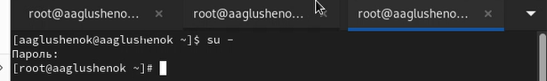

Задание 1

## Мониторинг журнала системных событий в реальном времени

2. На второй вкладке терминала запустите мониторинг системных событий в реальном времени: tail -f /var/log/messages

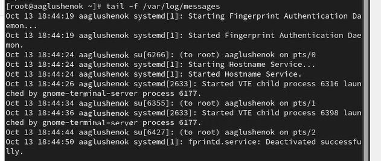

Задание 2

## Мониторинг журнала системных событий в реальном времени

3. В третьей вкладке терминала вернитесь к учётной записи своего пользователя (Ctrl + d ) и попробуйте получить полномочия администратора, но введите неправильный пароль. Во второй вкладке терминала с мониторингом событий появится сообщение «FAILED SU (to root) username …». Отображаемые на экране сообщения также фиксируются в файле /var/log/messages.

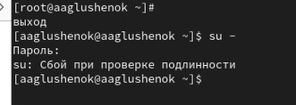

Задание 3

## Мониторинг журнала системных событий в реальном времени

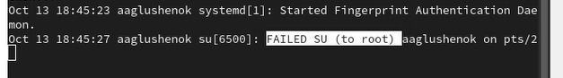

Задание 3

## Мониторинг журнала системных событий в реальном времени

4. В третьей вкладке терминала из оболочки пользователя введите logger hello. Во второй вкладке терминала с мониторингом событий вы увидите сообщение, которое также будет зафиксировано в файле /var/log/messages.
5. Во второй вкладке терминала с мониторингом остановите трассировку файла сообщений мониторинга реального времени, используя Ctrl + c. Затем запустите мониторинг сообщений безопасности (последние 20 строк соответствующего файла логов): tail -n 20 /var/log/secure. Вы увидите сообщения, которые ранее были зафиксированы во время ошибки авто- ризации при вводе команды su.

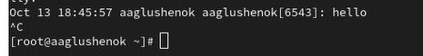

Задание 4-5

## Мониторинг журнала системных событий в реальном времени

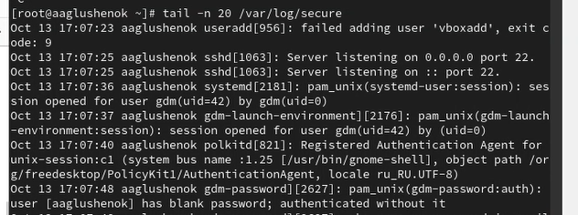

Задание 4-5

## Мониторинг журнала системных событий в реальном времени

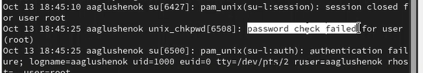

Задание 4-5

## Изменение правил rsyslog.conf

1. В первой вкладке терминала установите Apache, если он не был ранее инсталлирован: dnf -y install httpd

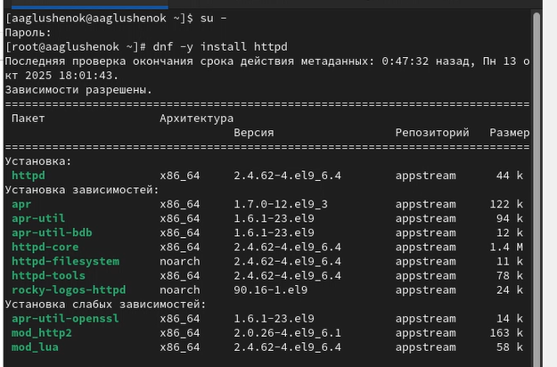

Задание 1

## Изменение правил rsyslog.conf

2. После окончания процесса установки запустите веб-службу: systemctl start httpd, systemctl enable httpd

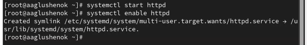

Задание 2

## Изменение правил rsyslog.conf

3. Во второй вкладке терминала посмотрите журнал сообщений об ошибках веб-службы: tail -f /var/log/httpd/error_log. Чтобы закрыть трассировку файла журнала, используйте Ctrl + c .

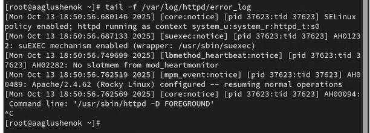

Задание 3

## Изменение правил rsyslog.conf

4. В третьей вкладке терминала получите полномочия администратора и в файле конфигурации /etc/httpd/conf/httpd.conf в конце добавьте строку: ErrorLog syslog:local1

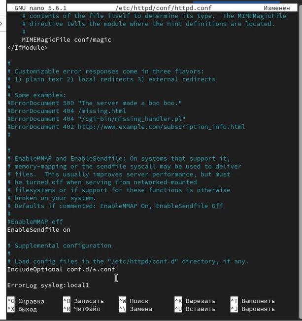

Задание 4

## Изменение правил rsyslog.conf

5. В каталоге /etc/rsyslog.d создайте файл мониторинга событий веб-службы: cd /etc/rsyslog.d, touch httpd.conf. Открыв его на редактирование, пропишите в нём local1.* -/var/log/httpd-error.log. Эта строка позволит отправлять все сообщения, получаемые для объекта local1 (который теперь используется службой httpd), в файл /var/log/httpd-error.log.

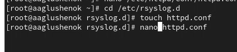

Задание 5

## Изменение правил rsyslog.conf

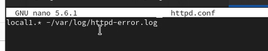

Задание 5

## Изменение правил rsyslog.conf

6. Перейдите в первую вкладку терминала и перезагрузите конфигурацию rsyslogd и веб-службу: systemctl restart rsyslog.service, systemctl restart httpd. Все сообщения об ошибках веб-службы теперь будут записаны в файл /var/log/httpd-error.log

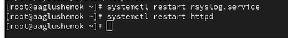

Задание 6

## Изменение правил rsyslog.conf

7. В третьей вкладке терминала создайте отдельный файл конфигурации для мониторинга отладочной информации: cd /etc/rsyslog.d, touch debug.conf. В этом же терминале введите echo “*.debug /var/log/messages-debug” > /etc/rsyslog.d/debug.conf

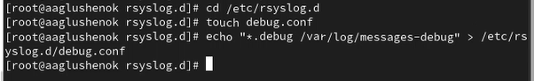

Задание 7

## Изменение правил rsyslog.conf

8. В первой вкладке терминала снова перезапустите rsyslogd: systemctl restart rsyslog.service

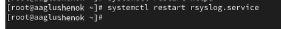

Задание 8

## Изменение правил rsyslog.conf

9. Во второй вкладке терминала запустите мониторинг отладочной информации: tail -f /var/log/messages-debug

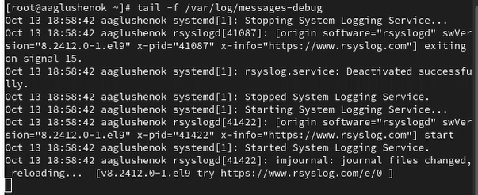

Задание 9

## Изменение правил rsyslog.conf

10. В третьей вкладке терминала введите: logger -p daemon.debug “Daemon Debug Message”

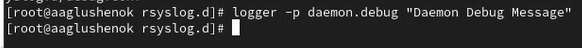

Задание 10

## Изменение правил rsyslog.conf

11. В терминале с мониторингом посмотрите сообщение отладки. Чтобы закрыть трассировку файла журнала, используйте Ctrl + c

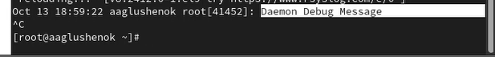

Задание 11

## Использование journalctl

1. Во второй вкладке терминала посмотрите содержимое журнала с событиями с момента последнего запуска системы: journalctl. Для пролистывания журнала используйте или Enter (построчный просмотр), или пробел (постраничный просмотр). Для выхода из просмотра используйте q .

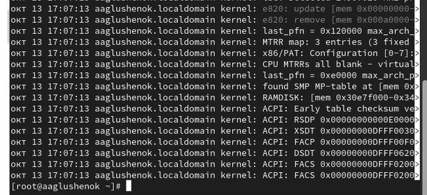

Задание 1

## Использование journalctl

2. Просмотр содержимого журнала без использования пейджера: journalctl –no-pager

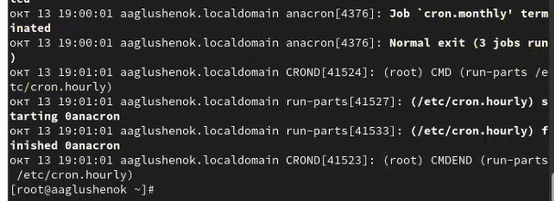

Задание 2

## Использование journalctl

4. Для использования фильтрации просмотра конкретных параметров журнала введите journalctl и дважды нажмите клавишу Tab .

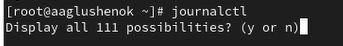

Задание 4

## Использование journalctl

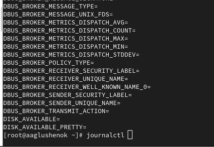

Задание 4

## Использование journalctl

5. Просмотрите события для UID0: journalctl _UID=0

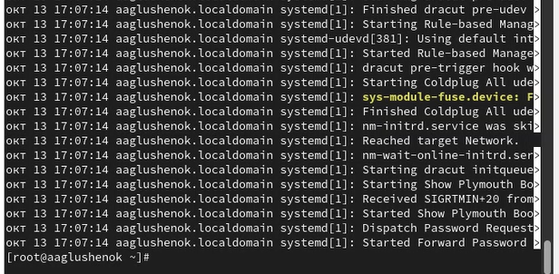

Задание 5

## Использование journalctl

6. Для отображения последних 20 строк журнала введите journalctl -n 20
7. Для просмотра только сообщений об ошибках введите journalctl -p err

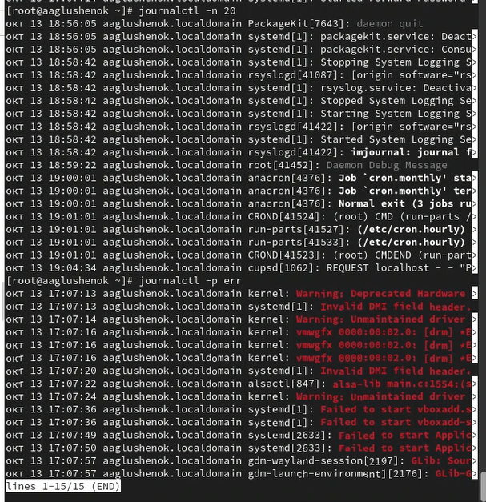

Задание 6-7

## Использование journalctl

8. Если вы хотите просмотреть сообщения журнала, записанные за определённый период времени, вы можете использовать параметры –since и –until. Обе опции принимают параметр времени в формате YYYY-MM-DD hh:mm:ss. Кроме того, вы можете использовать yesterday, today и tomorrow в качестве параметров. Например, для просмотра всех сообщений со вчерашнего дня введите journalctl –since yesterday

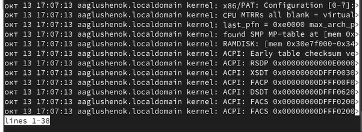

Задание 8

## Использование journalctl

9. Если вы хотите показать все сообщения с ошибкой приоритета, которые были зафиксированы со вчерашнего дня, то используйте journalctl –since yesterday -p err

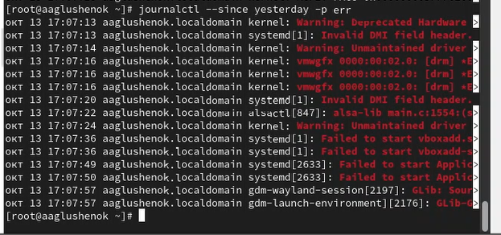

Задание 9

## Использование journalctl

10. Если вам нужна детальная информация, то используйте journalctl -o verbose

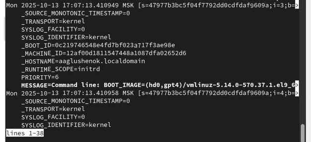

Задание 10

## Использование journalctl

11. Для просмотра дополнительной информации о модуле sshd введите journalctl _SYSTEMD_UNIT=sshd.service

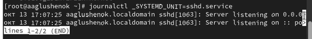

Задание 11

## Постоянный журнал journald

1. Запустите терминал и получите полномочия администратора.
2. Создайте каталог для хранения записей журнала: mkdir -p /var/log/journal
3. Скорректируйте права доступа для каталога /var/log/journal, чтобы journald смог записывать в него информацию: chown root:systemd-journal /var/log/journal, chmod 2755 /var/log/journal
4. Для принятия изменений необходимо или перезагрузить систему, или использовать команду: killall -USR1 systemd-journald
5. Журнал systemd теперь постоянный. Если вы хотите видеть сообщения журнала с момента последней перезагрузки, используйте: journalctl -b

## Постоянный журнал journald

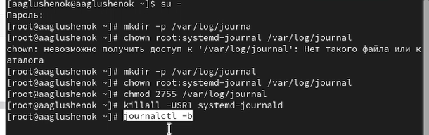

Задание 1-5

## Постоянный журнал journald

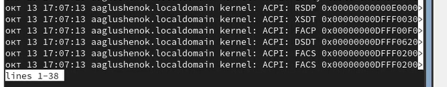

Задание 1-5

## Выводы

В ходе выполнения лабораторной работы №7 мне удалось получить навыки работы с журналами мониторинга различных событий в системе.

## Благодарю за внимание!